# GEDI ratio mode: Splicing

We check convergence of the GEDI model.

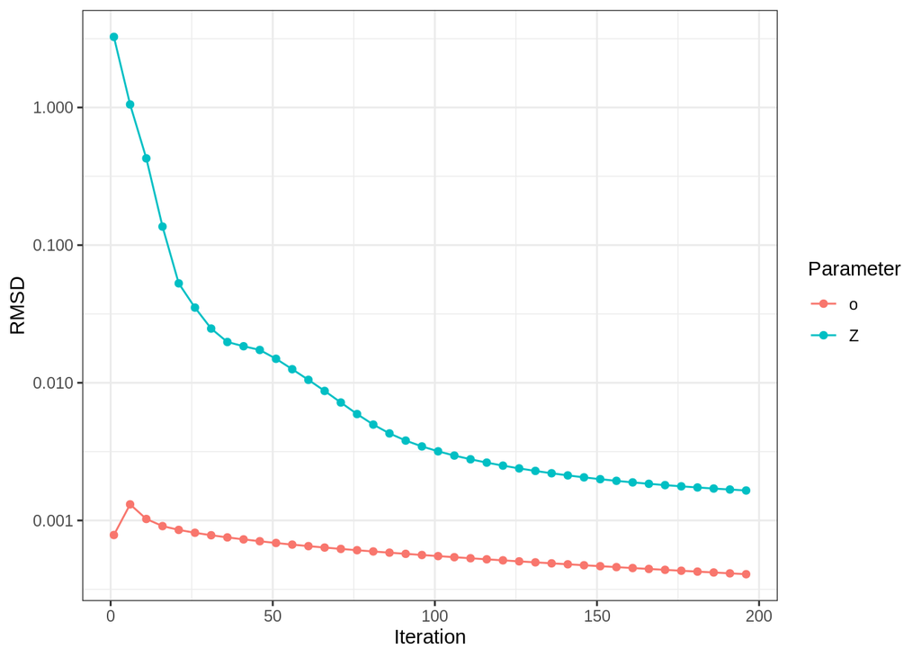

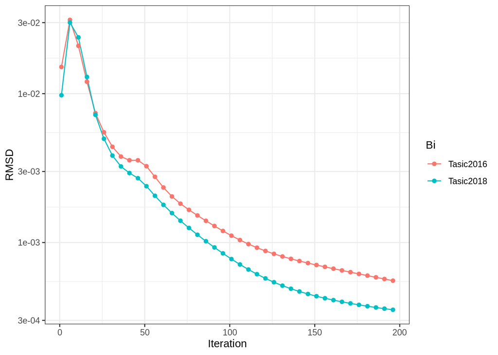

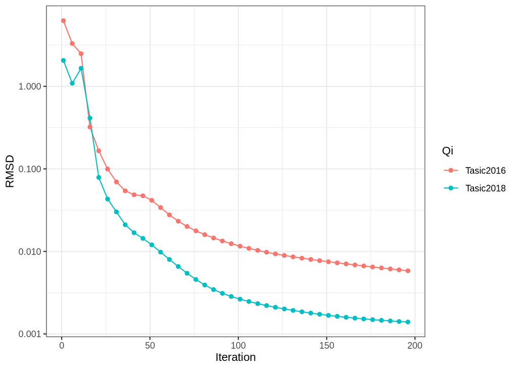

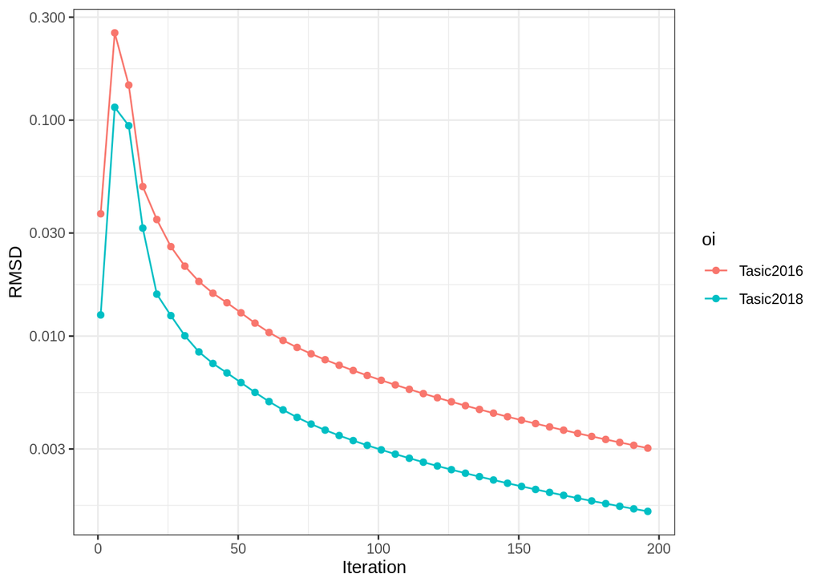

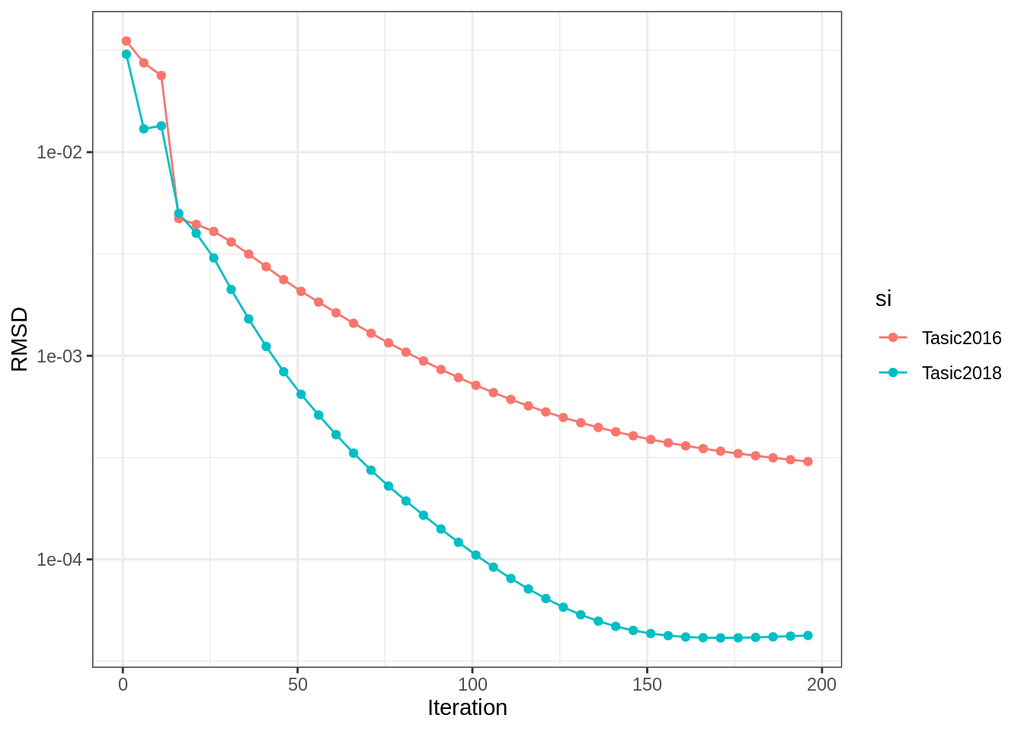

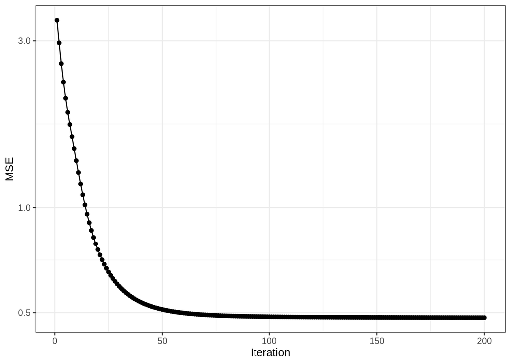

```r
model$plotTracking()
```

These plots show the convergence of the different components of the model (o, Z, Bi, Qi, oi and si). The last plot shows the convergence of the mean squared error of the model.

**IMPORTANT:** GEDI reorders the cells by sample, so we need to reorder the original metadata.

```r
# Reorder meta
meta<- meta[model$aux$cellIDs,]
```

# 03 - Visualize integration resuts

After running the model, we can recover the integrated reference space.

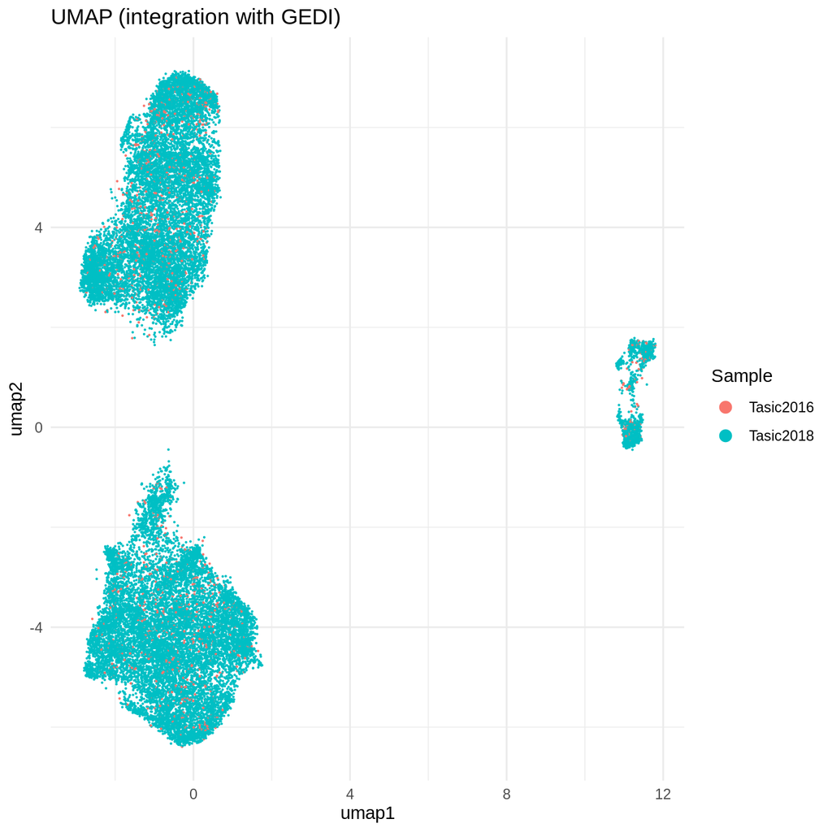

```r
# Generating svd
svd_res <- svd.gedi( model )
embedding_res_svd<- svd_res$v %*% diag(svd_res$d)
colnames(embedding_res_svd)<- paste0("embedding", 1:ncol(embedding_res_svd))

# Generating umap of 2 dimensions
umap_2_res <- umap(embedding_res_svd, min_dist=0.01, metric="euclidean")
colnames(umap_2_res)<- paste0("umap", 1:2)
rownames(umap_2_res)<- model$aux$cellIDs
umap_2_res<- data.frame(umap_2_res)

## Plot embeddings
GEDI::plot_embedding( umap_2_res, meta$Sample) + labs(x="umap1", y="umap2", title="UMAP (integration with GEDI)", color="Sample")
```

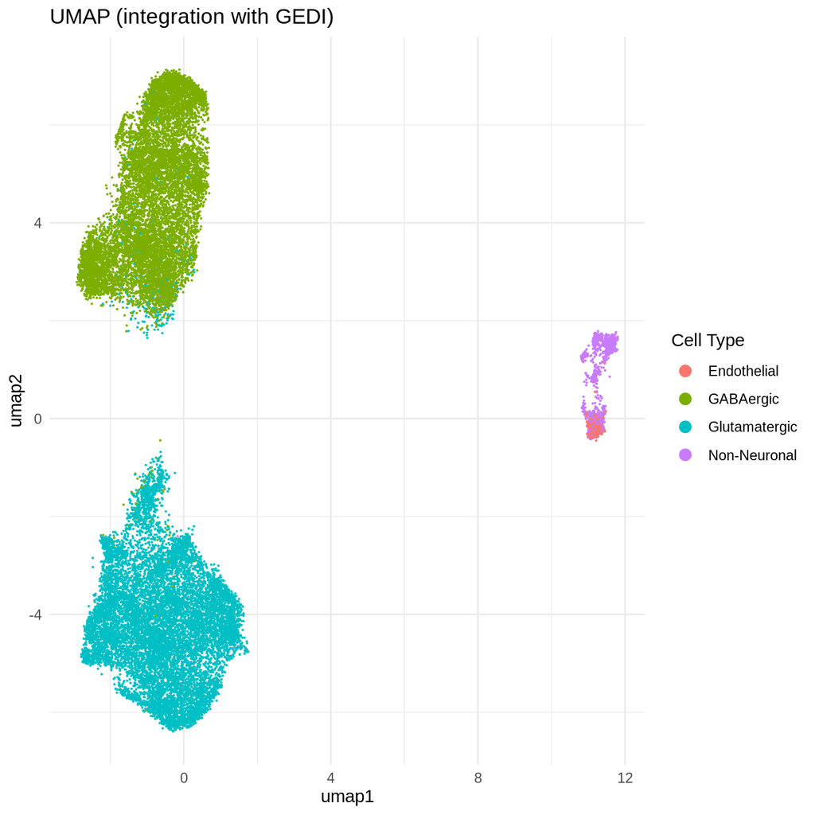

```r
GEDI::plot_embedding( umap_2_res, meta$major_cell_type) + labs(x="umap1", y="umap2", title="UMAP (integration with GEDI)", color="Cell Type")
```

Also, we can recover the imputed logit(PSI) from the GEDI model.

```r
imputedY<- GEDI::getY.gedi(model)
dim(imputedY)
```

```
## [1] 14267 25352
```

We can visualize the imputed logit(PSI) of some target genes.

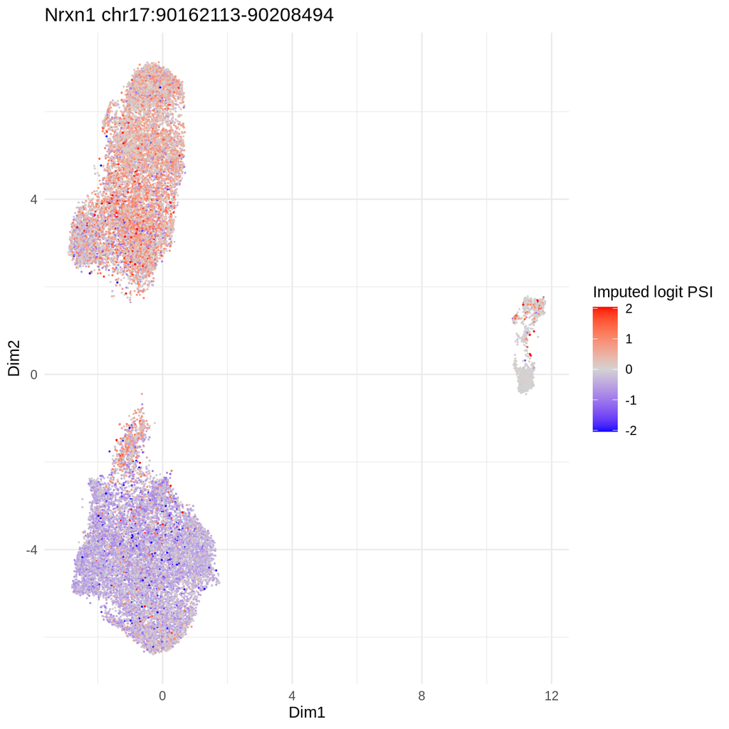

```r
# Exon skipping event for Nrxn1
# CA-18189-887480-931921-932011-933369[INC][12/3]
event_name<- "CA-18189-887480-931921-932011-933369[INC][12/3]"
plot_name<- "Nrxn1 chr17:90162113-90208494"
GEDI::plot_embedding(umap_2_res, imputedY[event_name,]) +
    labs(title=plot_name, color="Imputed logit PSI")
```

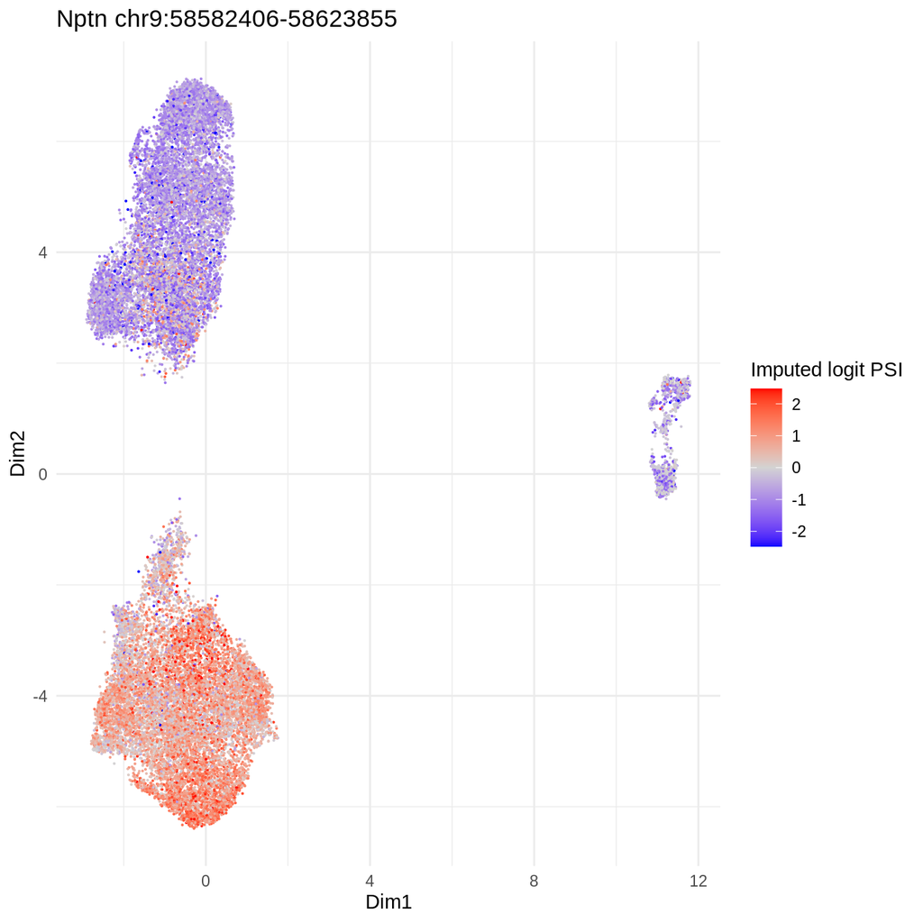

```r
# Exon skipping event for Nptn
# CA-20320-3287-39423-39771-44447[INC][8/120][UPT]
event_name<- "CA-20320-3287-39423-39771-44447[INC][8/120][UPT]"
plot_name<- "Nptn chr9:58582406-58623855"
GEDI::plot_embedding(umap_2_res, imputedY[event_name,]) +
    labs(title=plot_name, color="Imputed logit PSI")
```